# Final Project 1

Parker Lambert

2023-07-24

Name: Parker Lambert

Class: 103

Assignment: Final Project 1

Due: 7/25/23

# Final Project 1

### Libraries

```r
library(tidyverse)
```

```r
library(ggplot2)
library(tibble)
library(hrbrthemes)
# for part 3
library(vtable)
library(corrplot)
library(pheatmap)
library(ggridges)
```

### Import Data and Wrangle

```r
# importing data from file
GE <- read.csv("QBS103_finalProject_geneExpression.csv")
#summary(GE)
MD <- read.csv("QBS103_finalProject_metadata.csv")
# transpose the GE data table
TGE <- setNames(data.frame(t(GE[,-1])),GE[,1])
TGE2 <- tibble::rownames_to_column(TGE,'participant_id')
# linking the two data tables
df <- full_join(TGE2,MD,by = "participant_id")
#df
p2 <- df
```

## Identify from Data

### One Gene

The gene I have selected is `ABCF2` official name is: `ATP binding cassette subfamily F member 2`

It is a member of the ATP-Binding cassette transporter super-family. It helps with transport of various molecules across the extra- and intracellular membranes. Alterations in this gene may be involved in cancer progression.

*All information came from the: [National Library of Medicine](https://www.ncbi.nlm.nih.gov/gene/10061)*

### Continuous Covariate

The continuous covariate I selected is `ferritin.ng.ml`

### Two Categorical Covariates

The two categorical covariates are `sex` and `mechanical_ventilation`

## Histogram

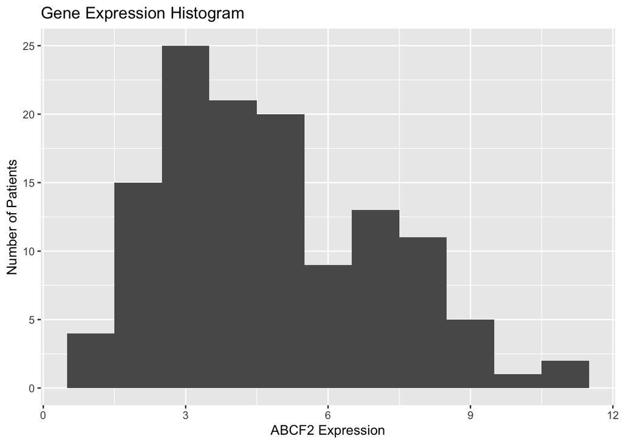

```r
# select gene
ggplot(df,aes(df$ABCF2)) +
  # choose histogram
  geom_histogram(binwidth = 1) +
  # add labels
  labs(title = 'Gene Expression Histogram',y= 'Number of Patients',x='ABCF2 Expression')# +
```

```r
  # make pretty
  #theme_ipsum()
```

## Scatterplot

```r
# select desired collumn
df2 <- df |>
  select(ferritin.ng.ml.,ABCF2)
# make ferritin an integer
df2$ferritin.ng.ml. <- as.integer(df2$ferritin.ng.ml.)
# remove na
#df2 |>
#  na.omit()
#summary(df2)
```

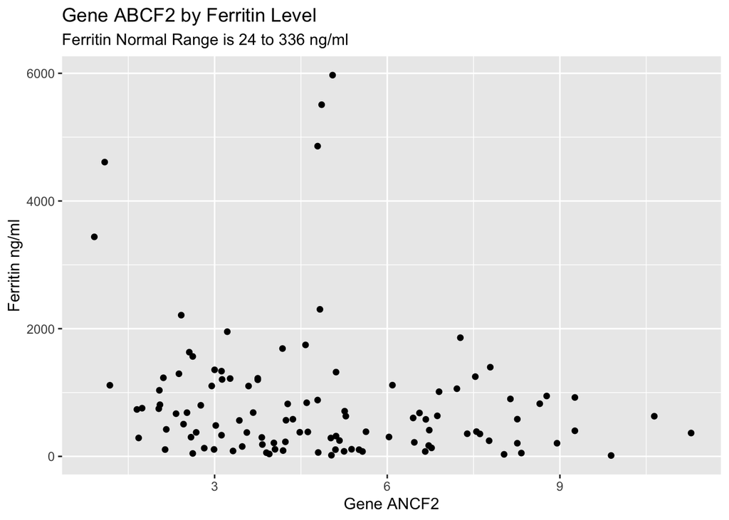

```r
# select collumns
ggplot(df2,aes(df2$ABCF2,df2$ferritin.ng.ml.)) +
  # choose scatterplot
  geom_point() +
  #label the plot
  labs(title = 'Gene ABCF2 by Ferritin Level',subtitle = 'Ferritin Normal Range is 24 to 336 ng/ml', x = 'Gene ANCF2', y = 'Ferritin ng/ml')# +
```

```r
  # make pretty by adding theme
  #theme_ipsum()
```

## Box Plot

```r
# make sex a factor
df$sex<-factor(df$sex)
# remove the unknwon
dff <- df[df$sex != " unknown",]
# refactor sex and save to new df
dff$sex <- factor(dff$sex, levels = c(' male', ' female'))
# make mechanical_ventilation a factor
dff$mechanical_ventilation <- factor(dff$mechanical_ventilation)
#dff$mechanical_ventilation
```

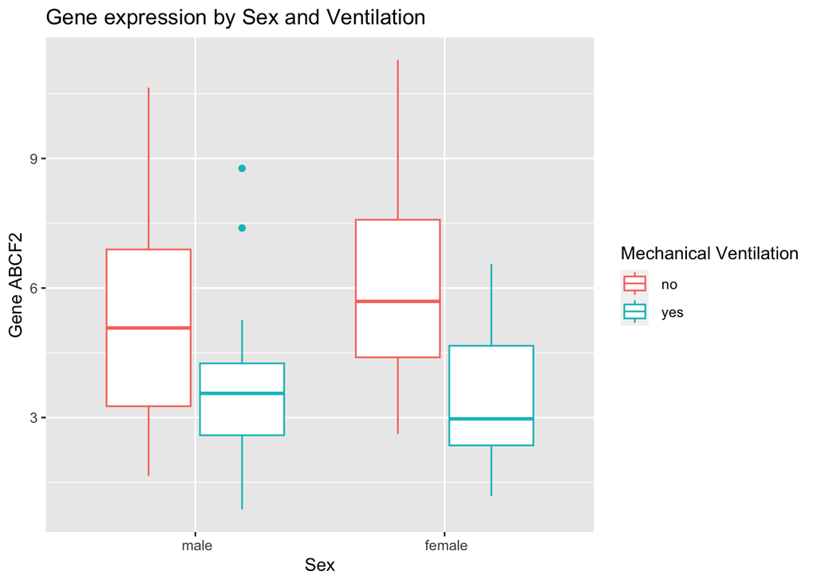

```r
# select columns
ggplot(data = na.omit(dff[,c('ABCF2','sex','mechanical_ventilation')]),aes(sex,ABCF2,color=mechanical_ventilation)) +
  # choose boxplot
  geom_boxplot() +
  # create labels
  labs(title = 'Gene expression by Sex and Ventilation',x = 'Sex', y = 'Gene ABCF2', color = 'Mechanical Ventilation') #+
```

```r
  # select theme
  #theme_ipsum()
```

# Final Project 2

Build a function to create the plots you made for Presentation 1, incorporating feedback you received from your first presentation on improving plot design (10 pts) Functions should take the following input:

1. The Name of the Data Frame
2. A list of 1 or more gene names
3. 1 Continuous Covariate
4. A list of 2 Categorical Covariates

```r
plot_vars <- function(data, gene, cont_var,cata_vars){
  # loop so that every gene is graphed 3 times
  for (gn in gene){
    plot_hist(data,gn)
    plot_scatter(data,gn,cont_var)
    plot_boxplot(data,gn,cata_vars)
  }
}
plot_hist <- function(data,gene){
  print(ggplot(data,aes_string(gene)) +
    geom_histogram(color='#ee7674',fill = '#f9b5ac') +
    labs(
      title = substitute(paste('Expression of ',italic(gene)), list(gene = gene)),
      x = substitute(paste(italic(gene)), list(gene = gene)),
      y = 'Number of Subjects'))
}
plot_scatter <- function(data,gene,cont_var){
  print(ggplot(data,aes_string(gene, cont_var)) +
    geom_point() +
    labs(
      title = substitute(paste(italic(gene), ' by ', cont_var), list(gene = gene,cont_var=cont_var)),
      x = cont_var,
      y = substitute(paste('Expression of ',italic(gene)), list(gene = gene))))
}
plot_boxplot <- function(data,gene,cata_vars){
  print(ggplot(data,aes_string(cata_vars[[1]],gene,color = cata_vars[[2]])) +
    # choose boxplot
    geom_boxplot() +
    labs(
      title = paste(gene, 'by', cata_vars[[1]], 'and', cata_vars[[2]],sep=' '),
      x = cata_vars[[1]],
      y = substitute(paste(italic(gene)), list(gene = gene)),
      color = cata_vars[[2]]))
}
```

```r
data2 <- df
data2$age <- as.integer(data2$age)
data2$ferritin.ng.ml. <- as.integer(data2$ferritin.ng.ml.)
data2 <- data2[!is.na(data2$age), ]
#plot_vars(data2, c('APOA1', 'CD24'), 'age',c('sex','mechanical_ventilation'))
```

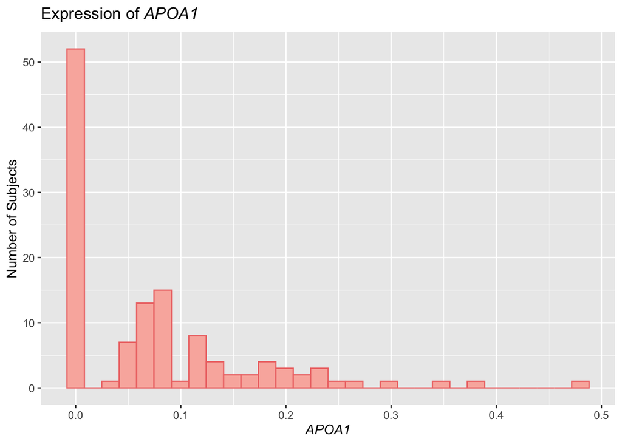

[figure not shown]

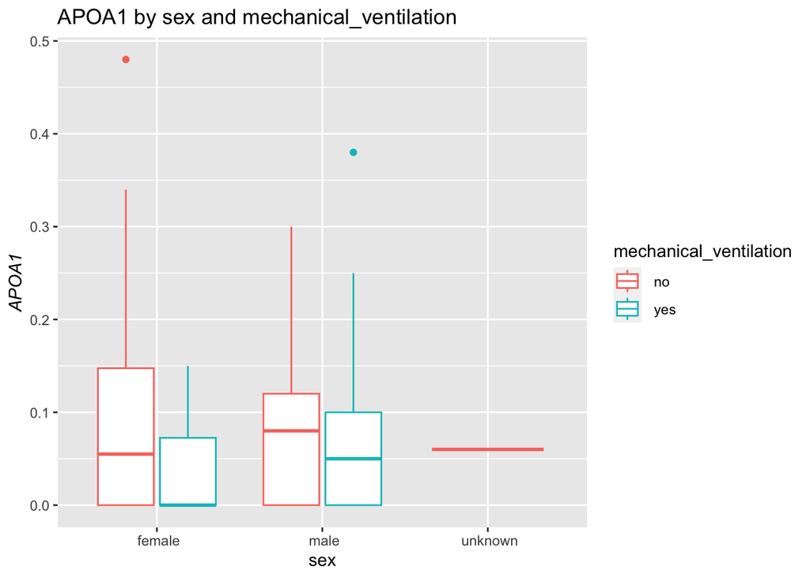

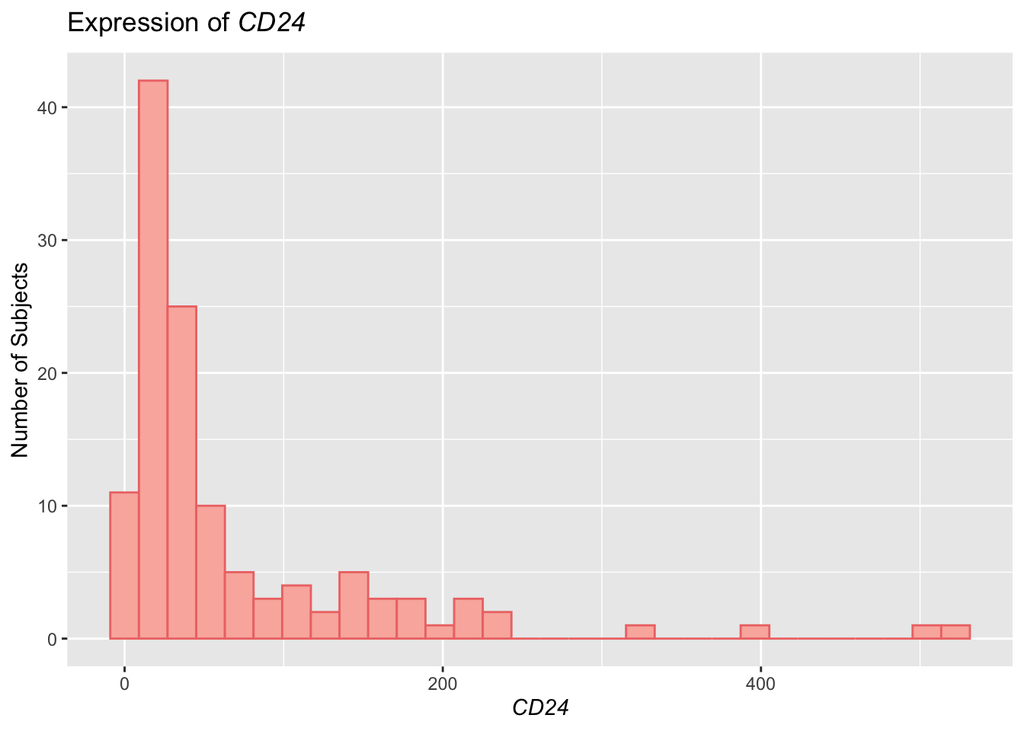

[figure not shown]

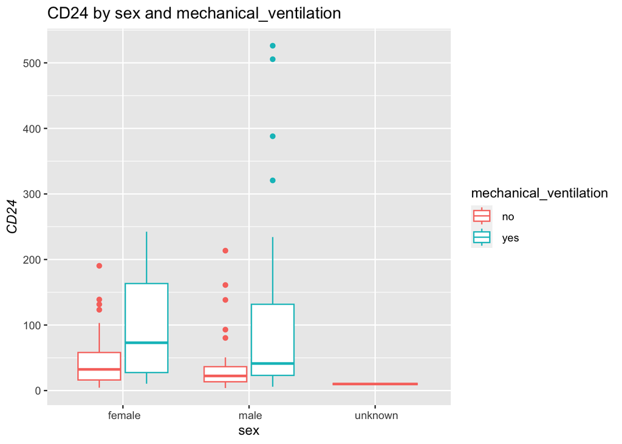

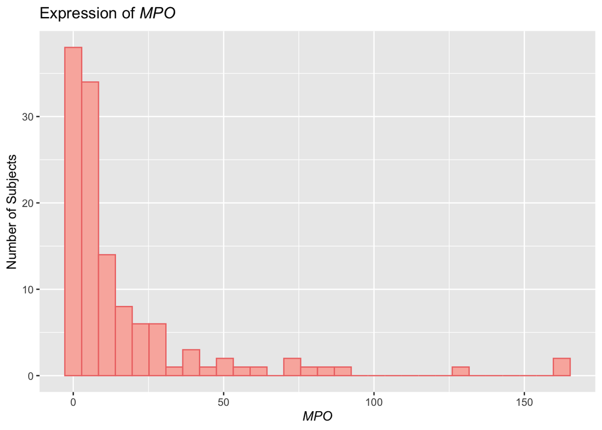

[figure not shown]

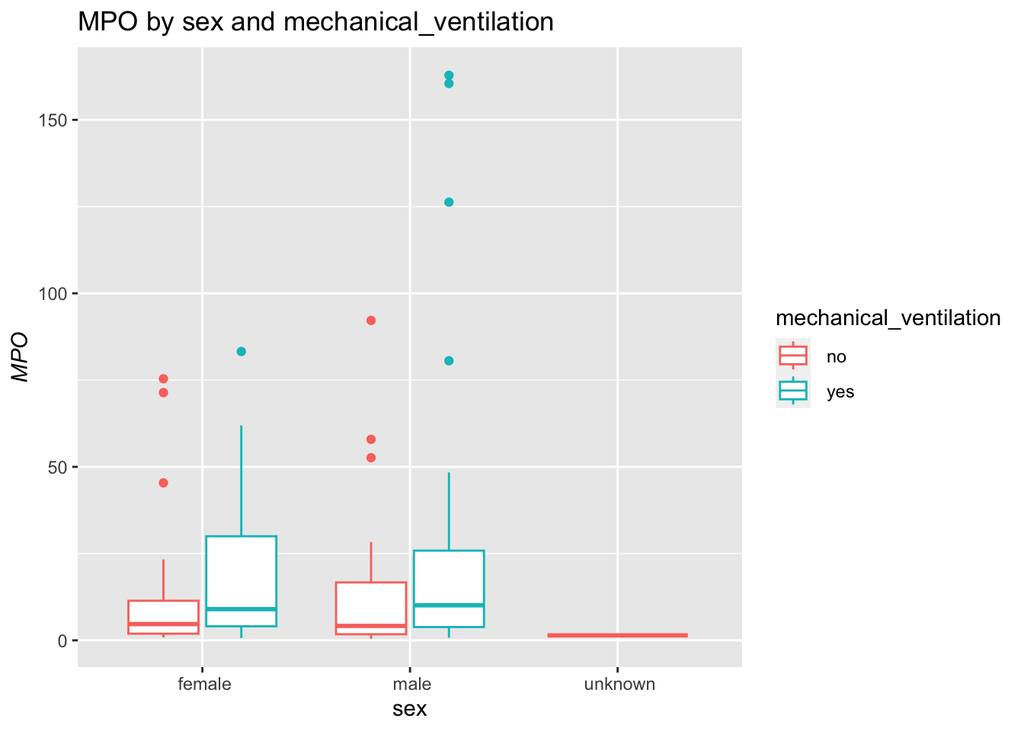

```r
plot_vars(data2, c('APOA1', 'CD24', 'MPO'), 'age',c('sex','mechanical_ventilation'))
```

# Final Project 3

## Table of Summary Statistics for Covariates

```r
# using function from the library vtable
data2 |>
  select('age','ferritin.ng.ml.','sex','mechanical_ventilation') |>
  sumtable()
```

Summary Statistics

| Variable | N | Mean | Std. Dev. | Min | Pctl. 25 | Pctl. 75 | Max |
| --- | --- | --- | --- | --- | --- | --- | --- |
| age | 123 | 61 | 16 | 21 | 50 | 74 | 88 |
| ferritin.ng.ml. | 107 | 851 | 1051 | 14 | 236 | 1102 | 5971 |
| sex | 123 |  |  |  |  |  |  |
| … female | 50 | 41% |  |  |  |  |  |
| … male | 72 | 59% |  |  |  |  |  |
| … unknown | 1 | 1% |  |  |  |  |  |
| mechanical_ventilation | 123 |  |  |  |  |  |  |
| … no | 72 | 59% |  |  |  |  |  |
| … yes | 51 | 41% |  |  |  |  |  |

## Final Figures

The feedback I received after the first round was:

1. Add Gene Name to plot titles and Italicize Gene Name.
2. Center titles and labeles and increase size.
3. Add horizontal bars indicating the normal range for ferritin and make histogram more readable with outline.

The feedback from the second round was:

1. Capitalize legends and titles where appropriate.
2. Remove unknowns and not it somewhere.
3. Center Titles.
4. Flip X and Y in scatter plot.

### Histogram

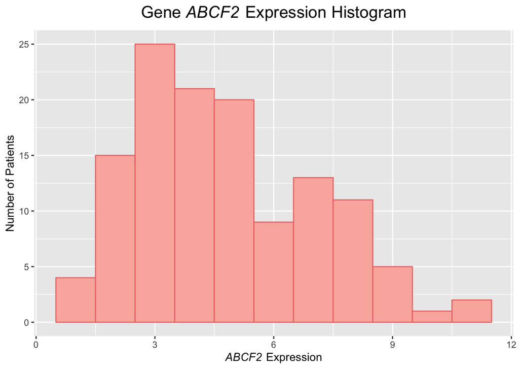

```r
# select gene
ggplot(df,aes(df$ABCF2)) +
  # choose histogram
  geom_histogram(binwidth = 1,color='#ee7674',fill = '#f9b5ac') +
  # add labels
  labs(
    title = substitute(paste('Gene ',italic('ABCF2'),' Expression Histogram')),
    y= 'Number of Patients',
    x= substitute(paste(italic('ABCF2'),' Expression'))
  ) +
  theme(plot.title = element_text(hjust = 0.5,size = 16))
```

### Scatterplot

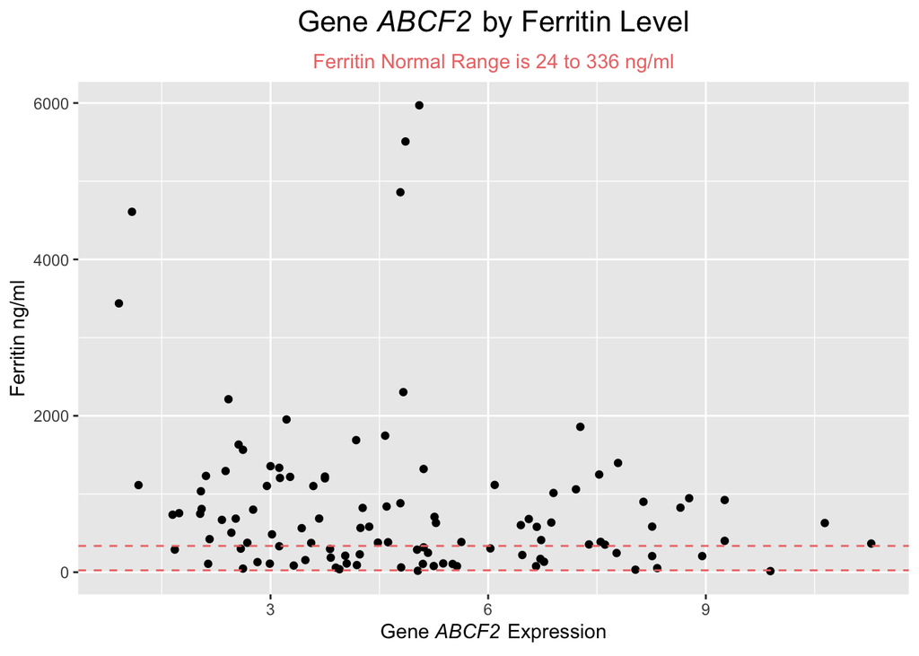

```r
# select collumns
ggplot(df2,aes(df2$ABCF2,df2$ferritin.ng.ml.)) +
  # choose scatterplot
  geom_point() +
  #label the plot
  labs(
    title = substitute(paste('Gene ',italic('ABCF2'),' by Ferritin Level')),
    subtitle = 'Ferritin Normal Range is 24 to 336 ng/ml',
    x = substitute(paste('Gene ',italic('ABCF2'),' Expression')),
    y = 'Ferritin ng/ml'
  ) +
  # add lines for normal range
  geom_hline(yintercept = 24,linetype = 'dashed' , color = '#ee7674') +
  geom_hline(yintercept = 336,linetype = 'dashed' , color = '#ee7674') +
  # center title
  theme(
    plot.title = element_text(hjust = 0.5,size = 16),
    plot.subtitle = element_text(hjust = 0.5, colour = '#ee7674')

    )
```

### Boxplot

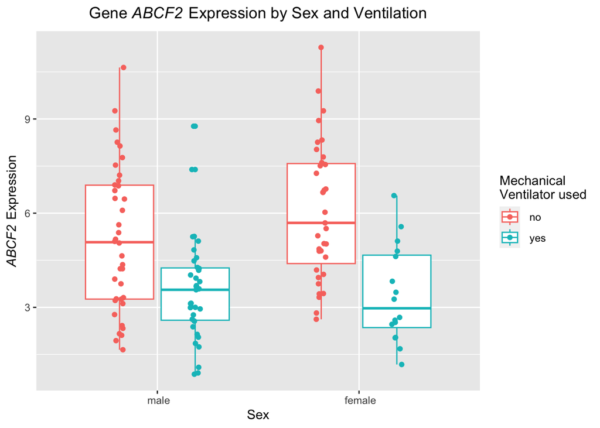

```r
# select columns
ggplot(data = na.omit(dff[,c('ABCF2','sex','mechanical_ventilation')]),aes(sex,ABCF2,color=mechanical_ventilation)) +
  # choose boxplot
  geom_boxplot() +
  # jitter points because others did
  geom_jitter(position = position_jitterdodge(jitter.width = 0.1)) +
  # create labels
  labs(
    title = substitute(paste('Gene ',italic('ABCF2'),' Expression by Sex and Ventilation')),
    x = 'Sex',
    y = substitute(paste(italic('ABCF2'),' Expression')),
    color = 'Mechanical \nVentilator used'
  ) +
  # select theme center title
  theme(plot.title = element_text(hjust = 0.5))
```

## Heatmap

```r
# data wrangling
corrDF <- df |>
  select('participant_id','APOA1','APOA2','MPO','ABCF3','VWF','A2M','BPI','AAMP','AARS2','AASS','sex','mechanical_ventilation')
```

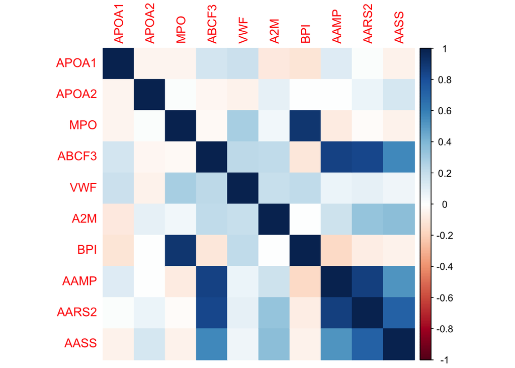

```r
# heat map

cor(corrDF[2:11], use = "complete.obs") |>
  corrplot(method = 'color')
```

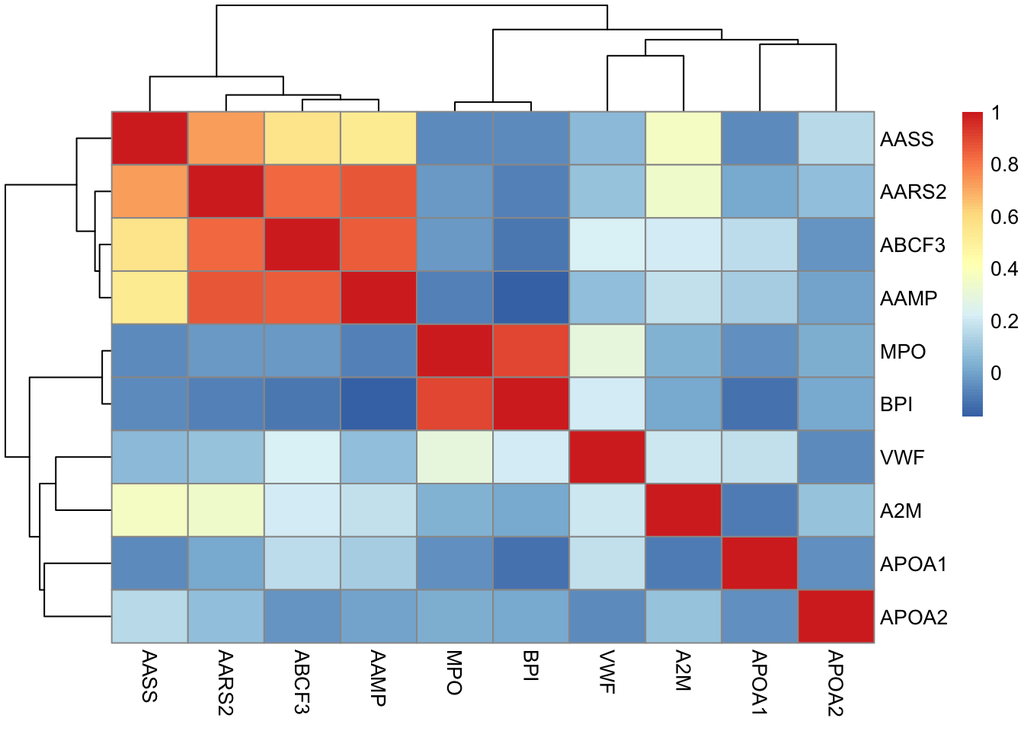

```r
pheatmap(
  cor(corrDF[2:11], use = "complete.obs"),
  cluster_distance_rows = 'euclidean',
  cluster_distance_cols = 'euclidean'
)
```

## Self Selected Plot

### Violin Plot

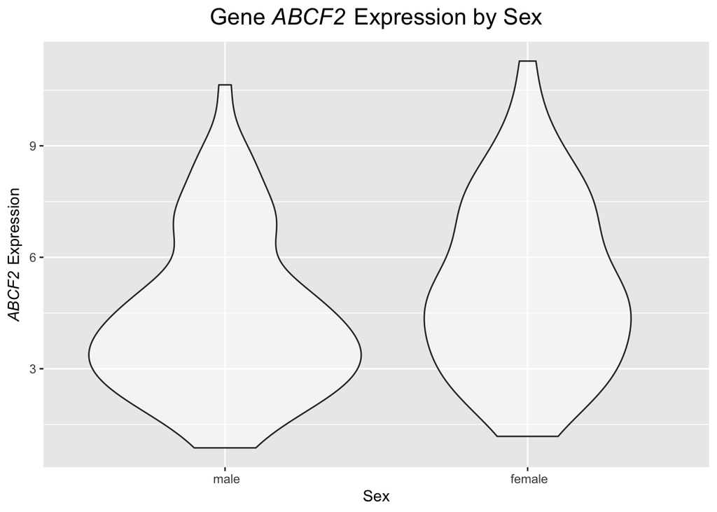

```r
# select columns
ggplot(data = na.omit(dff[,c('ABCF2','sex','mechanical_ventilation')]),aes(sex,ABCF2)) +
  # choose boxplot
  geom_violin(alpha = 0.5) +
  # create labels
  labs(
    title = substitute(paste('Gene ',italic('ABCF2'),' Expression by Sex')),
    x = 'Sex',
    y = substitute(paste(italic('ABCF2'),' Expression')),
    color = 'Mechanical \nVentilator used'
  ) +
  theme(plot.title = element_text(hjust = 0.5,size = 16))
```

### Density Plot

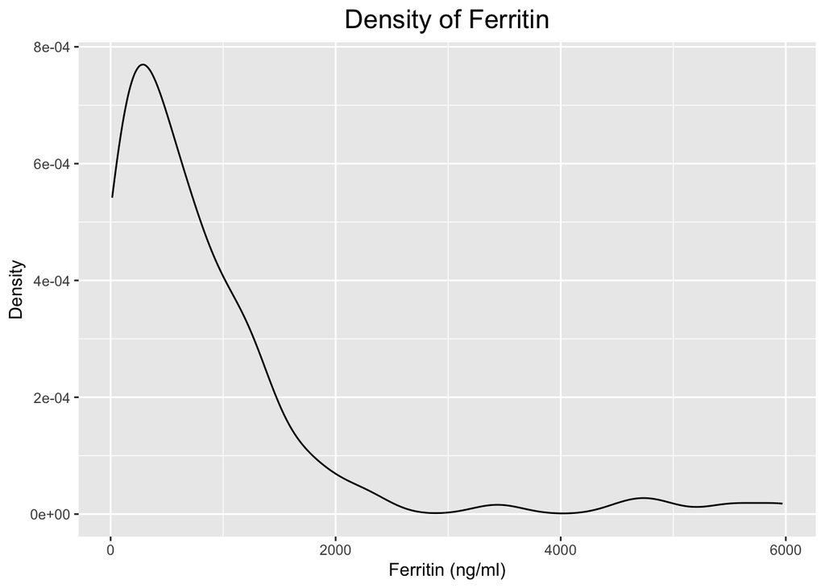

```r
ggplot(df2,aes(df2$ferritin.ng.ml.)) +
  geom_density() +
  labs(
    title = 'Density of Ferritin',
    x = 'Ferritin (ng/ml)',
    y = 'Density'
  ) +
  theme(
    plot.title = element_text(hjust = 0.5,size = 16))
```